# Centrální limitní věta: Cvičení

Kateřina Večerková vecerkok@vscht.cz

2025-07-03

# Centrální limitní věta: Cvičení

## Cvičení 1: Simulace populačního rozdělení

Vytvořte populační rozdělení pomocí nenormálního rozdělení (např. exponenciálního nebo rovnoměrného).  
- Nasimulujte populaci o 10 000 hodnotách.  
- Vykreslete rozdělení populace.

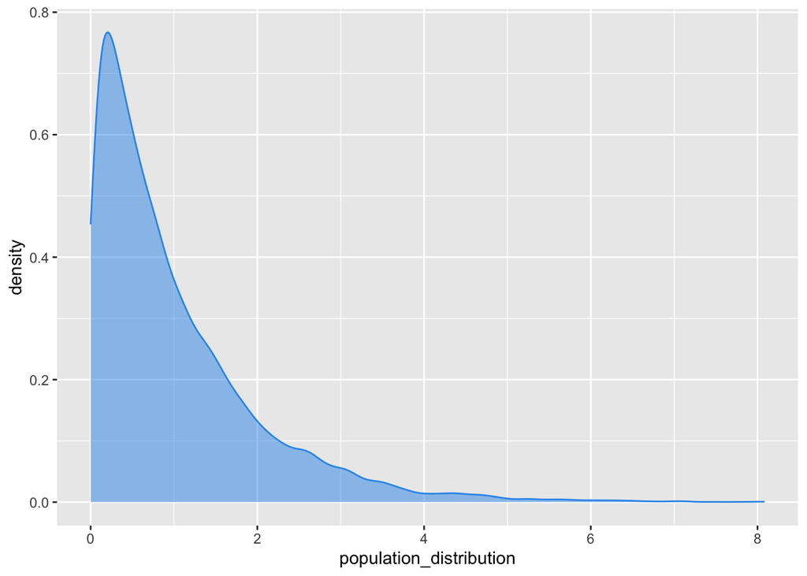

```r
library(ggplot2)
population_distribution <- rexp(10000, 1)
ggplot(as.data.frame(population_distribution), aes(x = population_distribution)) + geom_density(color = "#3498eb", fill = "#3498eb", alpha = 0.5)
```

## Cvičení 2: Vzorkování z populace

Vyberte náhodné vzorky z populace vytvořené v Cvičení 1.

- Vyberte 30 náhodných vzorků, každý o velikosti 50 pozorování.
- Spočítejte a uložte průměry těchto vzorků.

```r
random_samples <- replicate(30, sample(population_distribution, size = 50, replace = TRUE))
random_samples_means <- apply(random_samples, 2, mean)
random_samples_means
```

```
##  [1] 1.0756230 1.2692412 1.3534599 1.1144504 0.8955068 0.9901856 0.7446917
##  [8] 0.7620896 1.3246343 1.1894974 0.8563313 0.9300412 0.9900456 1.0231258
## [15] 0.8995077 0.8010468 0.9917519 0.9677312 0.9288422 1.0594850 1.1414782
## [22] 0.9454540 1.0546144 1.2394442 0.9254145 1.0014114 0.9228629 1.0314071
## [29] 1.1217605 0.7969149
```

## Cvičení 3: Rozdělení průměrů vzorků

Vykreslete rozdělení průměrů vzorků spočítaných v Cvičení 2.

- Použijte histogram nebo hustotní graf k vizualizaci rozdělení průměrů vzorků.

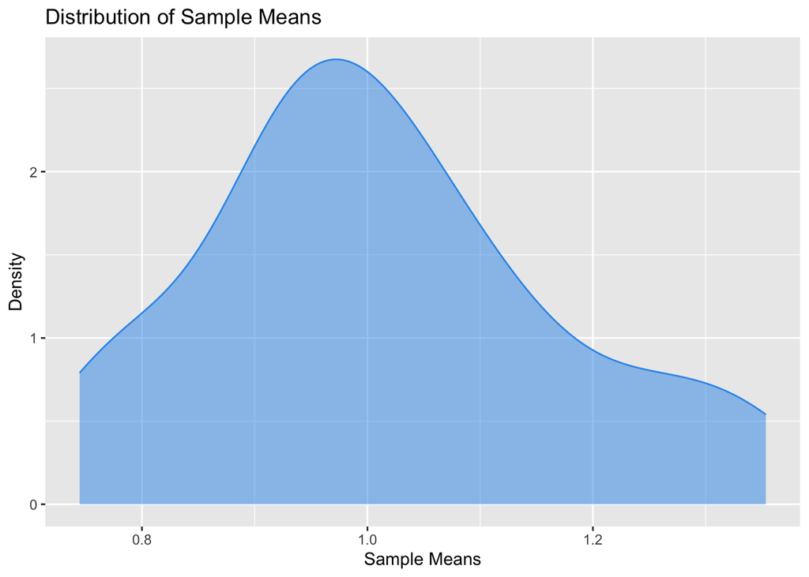

```r
ggplot(as.data.frame(random_samples_means), aes(x = random_samples_means)) + geom_density(color = "#3498eb", fill = "#3498eb", alpha = 0.5) + labs(title = "Distribution of Sample Means", x = "Sample Means", y = "Density")
```

## Cvičení 4: Ověření CLT

- Vytvořte funkci, která bude simulovat vzorkování z populace a vykreslí rozdělení průměrů vzorků.
- Otestujte funkci s různými velikostmi vzorku (např. 10, 30, 100) a pozorujte, jak se mění rozdělení průměrů vzorků.

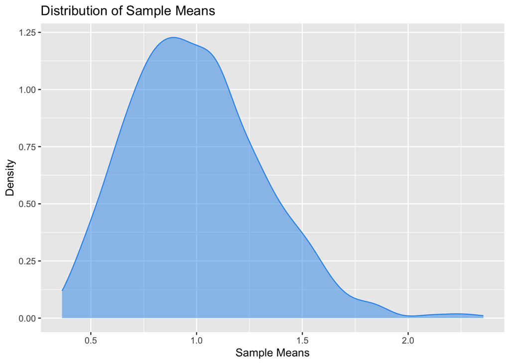

```r
plot_sample_means <- function(sample_size, num_samples, population_dist) {
  random_samples <- replicate(num_samples, sample(population_dist, size = sample_size, replace = TRUE))

  random_samples_means <- apply(random_samples, 2, mean)

  ggplot(as.data.frame(random_samples_means), aes(x = random_samples_means)) + geom_density(color = "#3498eb", fill = "#3498eb", alpha = 0.5) + labs(title = "Distribution of Sample Means", x = "Sample Means", y = "Density")
}

plot_sample_means(10, 1000, population_distribution)
```

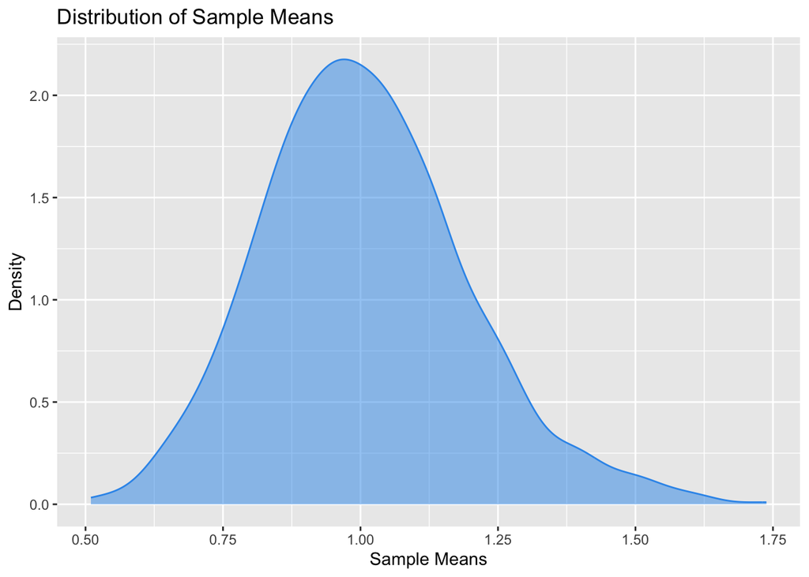

```r
plot_sample_means(30, 1000, population_distribution)
```

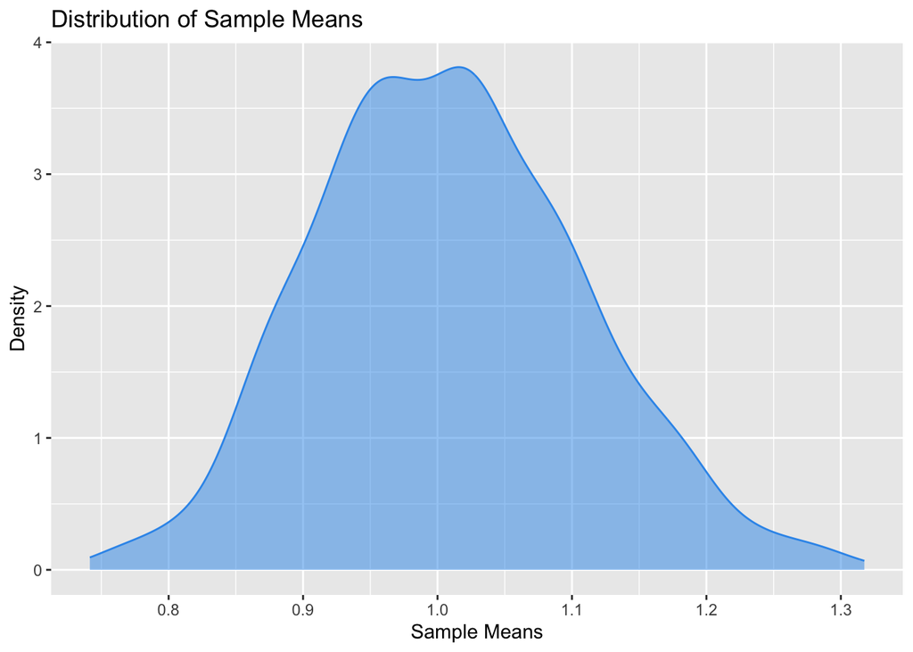

```r
plot_sample_means(100, 1000, population_distribution)
```